# Multiple Linear Regression

Dylan Maddux

2024-09-20

**The data contains observations on a sample of n = 804 used 2005 GM vehicles. For this exercise, we will only use the numeric variables in the dataset (including 0/1 indicator variables).**

### Part 1

**Question 1** Create a data visualization showing the relationship between mileage and suggested retail price. Which variable makes more sense to treat as the response variable? Describe any trends you observe in the graph.

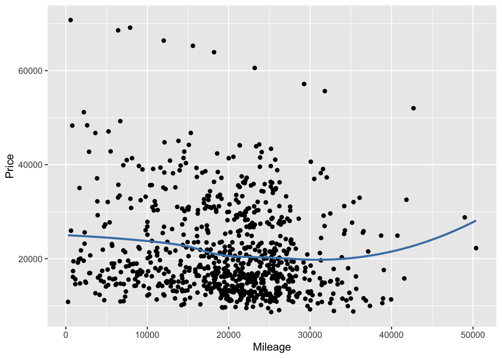

```r
library(ggplot2)
cars <- read.csv('data/Cars.csv')
ggplot(cars, aes(Mileage, Price)) +
  geom_point() +
  geom_smooth(se=F, color = "steelblue")
```

It would make more sense to treat Suggested Retail Price as the response variable since mileage should predict price. The graph displays a high level of variability at the low-to-mid price ranges, while at the higher prices a negative relationship between mileage and price seems to present itself.

**Question 2** Fit a simple linear regression model to the data using these two variables. Report the model formula, the t-value and p-value for the slope coefficient, and the residual standard error.

```r
lmod <- lm(Price~Mileage, cars)
summary(lmod)
```

```
##
## Call:
## lm(formula = Price ~ Mileage, data = cars)
##
## Residuals:
##    Min     1Q Median     3Q    Max
## -13905  -7254  -3520   5188  46091
##
## Coefficients:
##               Estimate Std. Error t value Pr(>|t|)
## (Intercept)  2.476e+04  9.044e+02  27.383  < 2e-16 ***
## Mileage     -1.725e-01  4.215e-02  -4.093 4.68e-05 ***
## ---
## Signif. codes:  0 '***' 0.001 '**' 0.01 '*' 0.05 '.' 0.1 ' ' 1
##
## Residual standard error: 9789 on 802 degrees of freedom
## Multiple R-squared:  0.02046,    Adjusted R-squared:  0.01924
## F-statistic: 16.75 on 1 and 802 DF,  p-value: 4.685e-05
```

Model Formula: Price = -0.1725Mileage + 24764.56

t-value: -4.093; p-value: 0.0000468; RSE: 9789

**Question 3** Does it seem that mileage is a strong predictor of price?

Mileage does not seem to be a strong predictor of price from the linear model. Although the p-value is very low, the variability is high as shown by the residual standard error, while the low R^2 shows that much of the variability in Price cannot be explained by Mileage. Furthermore, the scatterplot shows a high level of variance across data points and no clear linear relationship.

**Question 4** Why is mileage not a perfect predictor of price?

Mileage is not a perfect predictor of price because many other variables influence the retail price of the car, and mileage by itself is likely not a strong predictor of price. Other variables would include the original sale price of the car, the model and year, the size and features, and the physical condition, which would all factor into the final retail price.

### Part 2

**Question 1** Create a multiple linear regression model for suggested retail price as a function of the following predictors: Mileage, number of cylinders (Cyl), number of doors (Doors) engine size (Liter), whether the car has cruise control (Cruise; 1 = yes, 0 = no), whether the car has leather seats (Leather; 1 = yes, 0 = no), and whether the car has an upgraded sound system (Sound; 1 = yes, 0 = no).

```r
mlm <- lm(Price~Mileage+Cyl+Doors+Liter+Cruise+Leather+Sound, cars)
summary(mlm)
```

```
##
## Call:
## lm(formula = Price ~ Mileage + Cyl + Doors + Liter + Cruise +
##     Leather + Sound, data = cars)
##
## Residuals:
##    Min     1Q Median     3Q    Max
## -13278  -5615  -1556   3996  32819
##
## Coefficients:
##               Estimate Std. Error t value Pr(>|t|)
## (Intercept)  6.759e+03  1.877e+03   3.601 0.000337 ***
## Mileage     -1.698e-01  3.187e-02  -5.326 1.31e-07 ***
## Cyl          3.792e+03  6.832e+02   5.551 3.87e-08 ***
## Doors       -1.543e+03  3.205e+02  -4.814 1.77e-06 ***
## Liter       -7.872e+02  8.671e+02  -0.908 0.364196
## Cruise       6.289e+03  6.580e+02   9.558  < 2e-16 ***
## Leather      3.349e+03  5.977e+02   5.604 2.89e-08 ***
## Sound       -1.994e+03  5.718e+02  -3.487 0.000515 ***
## ---
## Signif. codes:  0 '***' 0.001 '**' 0.01 '*' 0.05 '.' 0.1 ' ' 1
##
## Residual standard error: 7388 on 796 degrees of freedom
## Multiple R-squared:  0.4463, Adjusted R-squared:  0.4414
## F-statistic: 91.64 on 7 and 796 DF,  p-value: < 2.2e-16
```

**Question 2** Give a clear and precise interpretation of the slope coefficient for Mileage in the context of the model. Price decreases by an average of $0.16975 per 1 mile increase in mileage in the context of this model, holding all else constant.

**Question 4** Review the estimated coefficients for each variable. Are any of the values surprising, given your prior knowledge about car prices?

I’m surprised that Engine size in Liters does not strongly correlate with Price since I would assume that a bigger engine means a bigger car, which would imply a higher price.

**Question 5** Identify the t-statistics and p-values for each of the variables in the model. Which variable had the smallest p-value? Which had the largest?

t-value: Mileage (-5.326), Cyl (5.551), Doors (-4.814), Liter (-0.908), Cruise (9.558), Leather (5.604), Sound (-3.487)

p-value: Mileage (1.31e-07), Cyl (3.87e-08), Doors (1.77e-06), Liter (0.364196), Cruise (< 2e-16), Leather (2.89e-08), Sound (0.000515)

Cruise control had the lowest p-value while Liter had the highest p-value.

**Question 6** For the p-value in the Mileage row, give a clear and precise statement of the hypothesis being tested.

The alternative hypothesis is that the slope of Mileage in the multivariate model significantly differs from 0 and thus has a p-value of $\alpha$ <0.05, therefore indicating that Mileage has an influence on the Retail Price.

**Question 7** In this case, the variable with the largest estimated coefficient does have the smallest p-value, but that is not necessarily true in general. Explain why not.

Variables with a greater range in the data will have smaller coefficients compared to variables with smaller ranges since small changes in value won’t influence the model as much. Therefore, a variable with a huge distribution of numbers such as mileage could have a low coefficient and low p-value, while another variable on a smaller scale of values could have a high coefficient and high p-value.

**Question 8** Compare the residual standard error statistic in this multivariate model to the one for the simple linear model in part 1. What does this suggest about your multivariate model?

The residual standard error statistic in this multivariate model is 7388 compared to 9789 for the simple linear model. This suggests that the multivariate model deviates less from the predicted values and therefore provides a more accurate estimate of the retail price.

**Question 9** Now compare the R^2 statistic from the multivariate model to the one from the simple linear model. What does this suggest about your multivariate model?

The R^2 statistic from the multivariate model is 44.63% compared to 2.05% for the simple linear model. This suggests that the combination of explanatory variables from the multivariate model explains more of the variability in the price than what only mileage itself explains.

### Part 3: Multicollinearity

**Question 1** Create the following three regression models with suggested retail price as the response. a. Mileage and Liter b. Mileage and Cyl c. Mileage, Liter, and Cyl

```r
mod1 <- lm(Price~Mileage+Liter, cars)
mod2 <- lm(Price~Mileage+Cyl, cars)
mod3 <- lm(Price~Mileage+Liter+Cyl, cars)
summary(mod1)
```

```
##
## Call:
## lm(formula = Price ~ Mileage + Liter, data = cars)
##
## Residuals:
##    Min     1Q Median     3Q    Max
##  -8817  -4990  -3337   3041  38568
##
## Coefficients:
##               Estimate Std. Error t value Pr(>|t|)
## (Intercept) 9426.60147 1095.07777   8.608  < 2e-16 ***
## Mileage       -0.16003    0.03491  -4.584 5.28e-06 ***
## Liter       4968.27812  258.80114  19.197  < 2e-16 ***
## ---
## Signif. codes:  0 '***' 0.001 '**' 0.01 '*' 0.05 '.' 0.1 ' ' 1
##
## Residual standard error: 8106 on 801 degrees of freedom
## Multiple R-squared:  0.3291, Adjusted R-squared:  0.3275
## F-statistic: 196.5 on 2 and 801 DF,  p-value: < 2.2e-16
```

```r
summary(mod2)
```

```
##
## Call:
## lm(formula = Price ~ Mileage + Cyl, data = cars)
##
## Residuals:
##    Min     1Q Median     3Q    Max
## -10264  -5121  -2838   3102  35477
##
## Coefficients:
##               Estimate Std. Error t value Pr(>|t|)
## (Intercept) 3145.75032 1325.93436   2.372   0.0179 *
## Mileage       -0.15243    0.03464  -4.401 1.22e-05 ***
## Cyl         4027.67463  204.61180  19.684  < 2e-16 ***
## ---
## Signif. codes:  0 '***' 0.001 '**' 0.01 '*' 0.05 '.' 0.1 ' ' 1
##
## Residual standard error: 8042 on 801 degrees of freedom
## Multiple R-squared:  0.3398, Adjusted R-squared:  0.3382
## F-statistic: 206.2 on 2 and 801 DF,  p-value: < 2.2e-16
```

```r
summary(mod3)
```

```
##
## Call:
## lm(formula = Price ~ Mileage + Liter + Cyl, data = cars)
##
## Residuals:
##    Min     1Q Median     3Q    Max
##  -9552  -4905  -3026   2445  36246
##
## Coefficients:
##               Estimate Std. Error t value Pr(>|t|)
## (Intercept) 4707.61500 1602.86565   2.937  0.00341 **
## Mileage       -0.15443    0.03461  -4.461 9.31e-06 ***
## Liter       1545.25224  893.41064   1.730  0.08409 .
## Cyl         2847.93446  712.04020   4.000 6.93e-05 ***
## ---
## Signif. codes:  0 '***' 0.001 '**' 0.01 '*' 0.05 '.' 0.1 ' ' 1
##
## Residual standard error: 8032 on 800 degrees of freedom
## Multiple R-squared:  0.3423, Adjusted R-squared:  0.3398
## F-statistic: 138.8 on 3 and 800 DF,  p-value: < 2.2e-16
```

**Question 2** Compare the p-values for the coefficients in the three models. In which models was Liter a “statistically significant” predictor of Price? In which models was Cyl a “statistically significant” predictor of Price?

Liter was a statistically significant predictor of Price in the model with Mileage as the only other explanatory variable. Cyl was a statistically significant predictor of Price in both models.

**Question 3** How does the residual standard error value compare across the three models? How does the estimated slope for Mileage compare across the three models? How do the estimated slopes for Cyl and Liter compare across the models?

The residual standard error values and slopes for Mileage are similar across all 3 models, with the 1st model having the highest RSE and Mileage slope by a small margin. The estimated slopes for Cyl and Liter are very different, with the 3rd model having a much lower slope compared to the 1st and 2nd models since more explanatory variables are included.

**Question 4** Create a plot showing the relationship between Cyl and Liter, and calculate the correlation coefficient between the two. Is there a strong relationship between them?

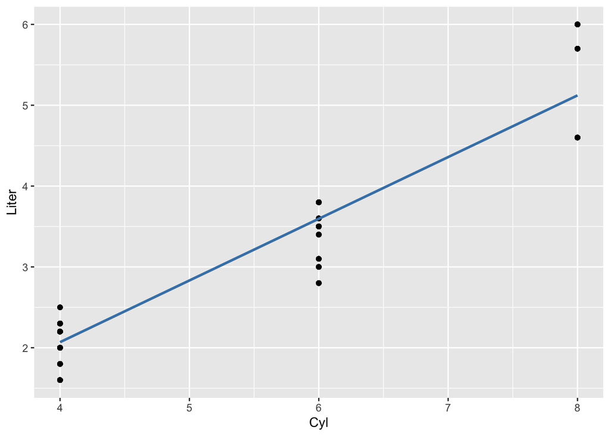

```r
ggplot(cars, aes(Cyl, Liter)) +
  geom_point() +
  geom_smooth(method = "lm", se=F, color = "steelblue")
```

```r
cor(cars$Cyl, cars$Liter)
```

```
## [1] 0.9578966
```

The scatterplot and high R value of 95.79% appear to indicate a strong relationship between the two variables.